# R Notebook

# Advanced ggplot2 Homework

## 1.1 Learning Objectives

- Practice making plots with ggplot2
- Create your own theme and use it with plots

```r
library(CodeClanData)
library(tidyverse)
library(scales)
```

# 2 MVP

## 2.1 Part 1

### Question 1

Take the data in the dataset qb_revenue_breakdown and make a stacked bar chart showing the sources of revenue across the two years in the dataset

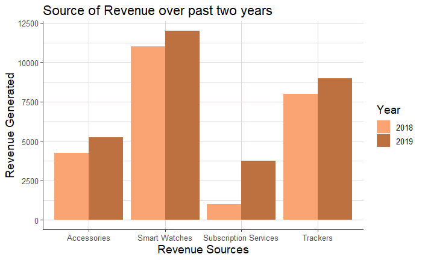

### Question 2

Make a line chart showing monthly sales of the “flagship product” - the ‘KwikBit Unit 1’ - over the last year. This data is inside qb_monthly_sales, but you will need to use filter or subset

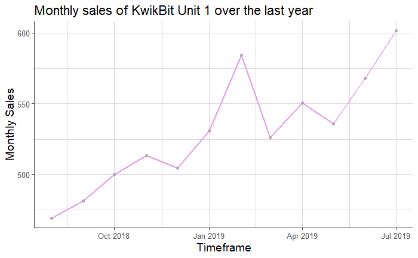

### Question 3

Make a line chart showing monthly revenue and costs over the last year. This data is also in qb_monthly_sales

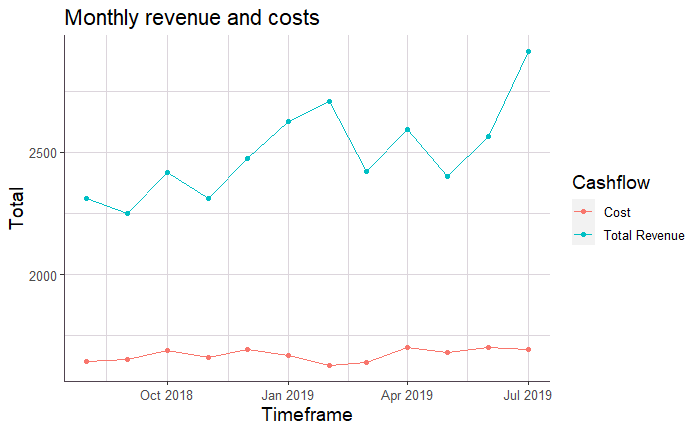

### Question 4

Show annual sales of personal fitness trackers over the last 5 years broken down by company as a ribbon plot(use geom_area). This data is in qb_competitors

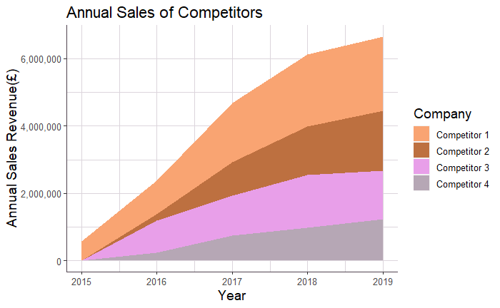

### Question 5

Now show the sales from the four competitors as a line graph. Include an extra layer that shows the data points used to make the lines.

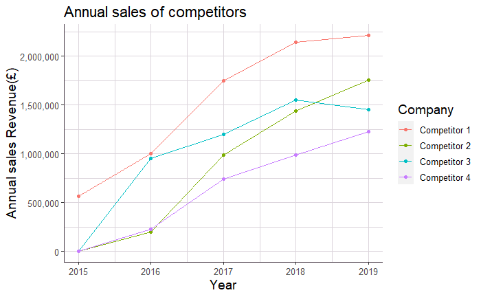

### Question 6

Now the company wants to compare the number of steps that their device counts vs their competitors. Make a line graph of the number of steps throughout time, and use faceting to compare between companies and people. The data for this is in qb_device_data.

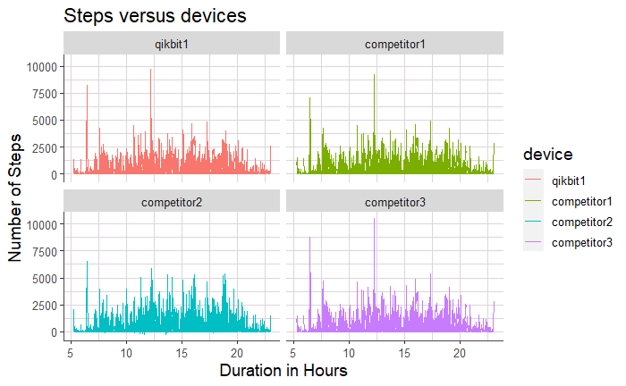

```r
hwl <- list(hw_theme + col_scheme)
```

[output not shown]